# Effect of Diversity on Success of Hollywood

Safal Shrestha

2023-05-19

## Introduction

Inclusion in Hollywood is a topic of great importance and coverage. This study will explore the effect of the ethnic composition of the lead and supporting cast of Hollywood movies on the box office. We will further study this effect overseas, specifically in two countries: China and United Kingdom. This is to mainly see if ethnic diversity in the cast has different effects on the box office in countries with different cultural values. United Kingdom and China are two of the biggest markets for Hollywood. Moreover, United Kingdom can be considered having more cultural affinity with the US than China. Through this study, we’ll check if this closeness actually plays any role in the success of a Hollywood movie.

First, the report will go through exploratory analysis where we’ll look into the overall trend of ethnic and gender composition in top 11 Hollywood movies (by box office earnings in USA and Canada) per year from 2010-2022.

Second, we’ll look into the effect of ethnic composition of the leading cast on the success of movies in the domestic market (US and Canada).

Finally, we’ll look into the effect of ethnic composition of leading cast + supporting cast on the success of movies in the UK and China markets.

All the data used for this analysis comes from [The Numbers website](https://www.the-numbers.com/) for box office data and [Namsor API](https://namsor.app/) for gender and ethnicity prediction from names. [1]

## Discussion

In our analysis, we are gathering box office information for the top 11 movies from the rank of best earning in the domestic market from 2010 to 2022. First, we’ll take a closer look into the ethnic composition of these top Hollywood movies and the trend over the years.

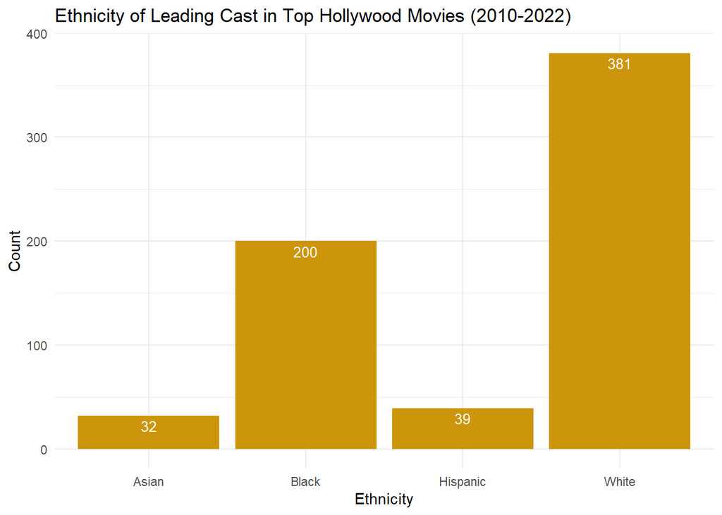

This graph details the ethnicity count of the leading casts of top 11 Hollywood movies for every year from 2010 to 2022. This clearly shows that majority of them are white, followed by Black Non-Latino, Hispanic, and Asian.

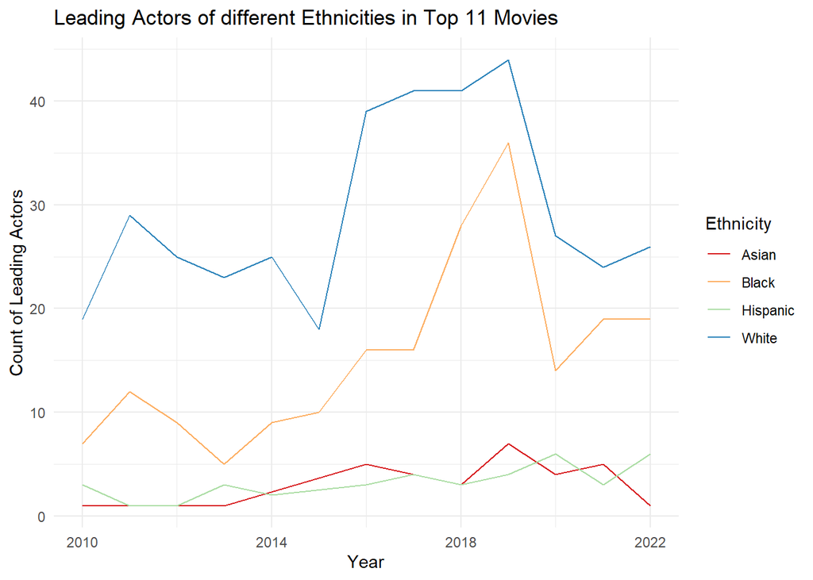

This graph again shows that the dominant race is white for leading cast in Hollywood for every year from 2010 to 2022. Meanwhile, Asian and Hispanic actors seem to be under-represented.

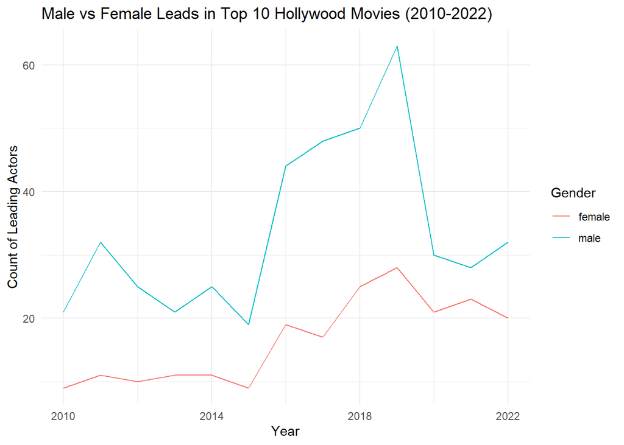

The story is similar in case of gender as well. Male representation is much higher in leading roles than females.

The results discussed above are expected. They clearly show the disparity in representation of minorities in the Hollywood industry. Now, we’d like to analyze the impact of ethnic diversity on the success of a movie on box office. We can first try to see this relationship visually. In this case, all the minority ethnicities are grouped together for simplicity.

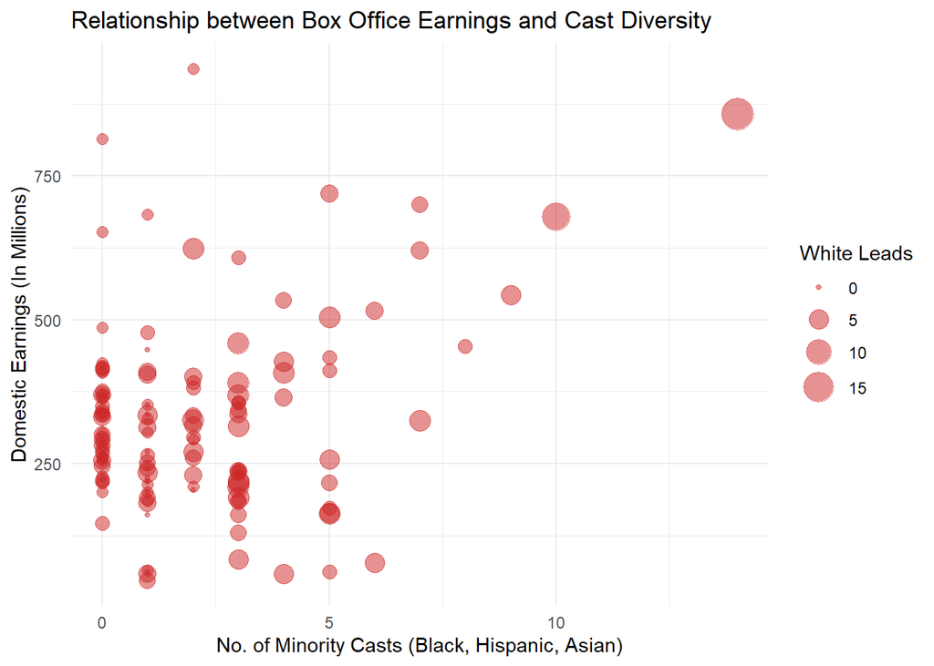

This graph gives us some indication that a diverse cast can actually lead to more success in the box office. Although there are movies with no minority leads at all that have performed well, we find that there are multiple instances where movies with combination of minority and white casts have performed quite well. It is possible that movies with more minorities are performing well because it also includes more white leads and a larger budget. In our graph, there aren’t many cases of highly performing movies that has only minority leads. The relationship presented by this graph needs to be further scrutinized and studied.

Upon further exploring this relationship, we find that, a higher number of cast leads to better domestic box office earnings. More importantly, the relationship shows that inclusion of only white actors in leading roles can negatively affect domestic box office earnings. Therefore, although there can be a significant number of white leads in a movie, adding minorities in leading roles as well actually leads to more success. There are definitely some other factors in play that could provide some more explanation. For example, a larger number of white and minority cast may speak to the quality of the movie and its budget. These kind of movies may be succeeding because of the distributor backing them. However, this result gives us some indication of the benefit of having diverse leads in a movie. Please refer to [2, 3, 4] for a closer look.

Now, we’d also like to see if this relationship is present in other countries as well. We’d like to choose countries that are the biggest market for Hollywood.

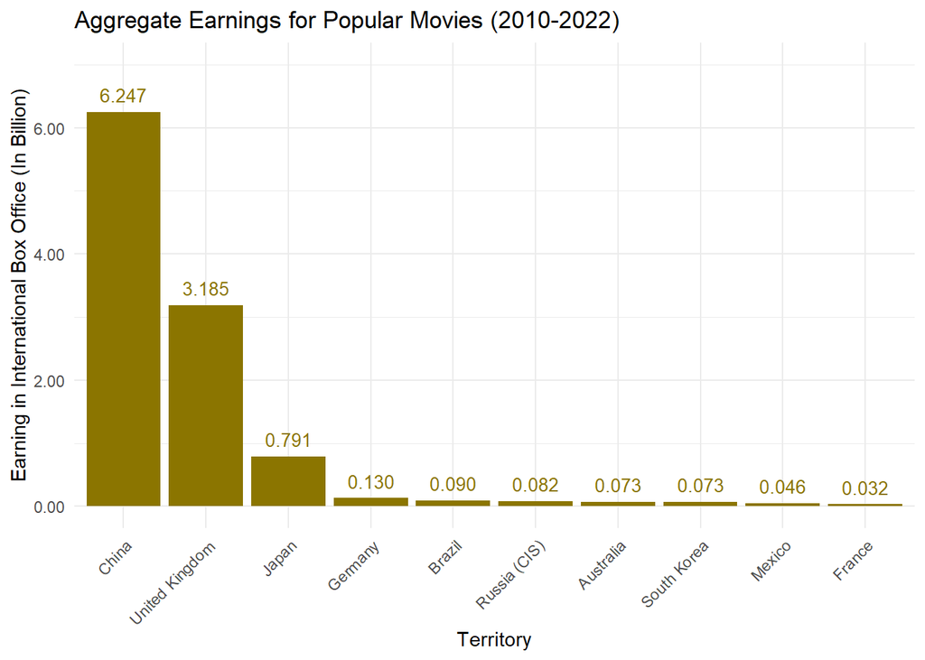

This graph shows us that China is actually the biggest market for Hollywood movies for the period of 2010-2022 based on the top 11 highest grossing movies. Following that, there’s United Kingdom. We’ll choose these two countries as they are culturally different and see if this difference makes an impact on the effect of diversity on the box office. We’ll take all the movies from our dataset that have released in both the United Kingdom and China. For this case, along with the leading roles, we’ll factor in ethnicity of the supporting cast as well since its a smaller sample of movies.

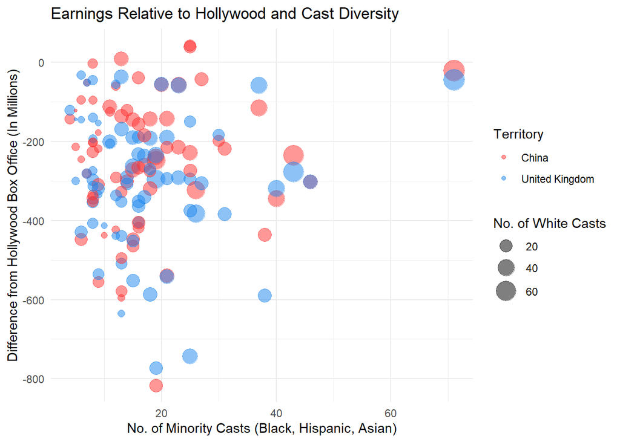

For China and UK, the relationship seems a bit ambiguous. The y axis shows how much a movie earned in China or UK relative to what it earned in the domestic market. Negative values just mean that the movie earned less than it did in the domestic market. Assuming that China and UK have different kinds of effect on the box office, such an analysis shows some indication that movies in China perform better than in the United Kingdom. Surprisingly, it also indicates that having a diverse cast actually leads to lower performance. However, these results could be a result of randomness and further scrutiny is needed to actually make any specific claims about this relationship. Please refer to [4, 5] for a closer look.

## Conclusion

This report explored the relationship between the ethnicity of the cast in top Hollywood movies and box office earnings. In the first phase, we explored the general summary of our dataset with ethnic composition of movies, international box office performance, etc. Second, we looked into how diversity affects the box office in the domestic market. Then, we also explored the possibility whether this relationship is affected by where the movie is released. There are a lot of confounding variables involved in the study of such a relationship between ethnic diversity and box office performance. Distributor of the movies, centrality of characters, and content of the movie itself could be some factors that affect this relationship. However, this study acts as a good overview of what could be happening in the industry. Especially in the recent years, minority representation has progressed and our study shows, at least in the domestic market, that diversity actually positively affects box office performance. For an international market like China and United Kingdom, an assumption that cultural values might affect a movie performance could be more complicated. Factors like actors, content, etc. might be more influential than cultural factors.

## Appendix

[1] All the data scraped from the numbers website is available here: [https://github.com/safal312/hollywood_demographics_analysis]

[2] Regression table for “domestic_box_office ~ white + minorities + white * minorities”

|  | *Dependent variable:* |
| --- | --- |
|  | Domestic Box Office |
| White Cast | -11,568,618.000 |
|  | (9,246,005.000) |
| Minority Cast | 4,095,011.000 |
|  | (8,885,635.000) |
| White X Minorities | 2,885,048.000*** |
|  | (1,045,505.000) |
| Constant | 321,236,152.000*** |
|  | (26,755,425.000) |
| Observations | 130 |
| R<sup>2</sup> | 0.143 |
| Adjusted R<sup>2</sup> | 0.122 |
| Residual Std. Error | 151,674,543.000 (df = 126) |
| F Statistic | 6.988*** (df = 3; 126) |
| *Note:* | p<0.1; p<0.05; p<0.01 |

[3] Breusch Pagan Test for the model above. Here, since the p-value is greater than 0.05, we can loosely accept that there is homoskedaticity in our model. However, more analysis might be required to further confirm this.

```
##
##  studentized Breusch-Pagan test
##
## data:  model
## BP = 4.8024, df = 3, p-value = 0.1869
```

[4] Graph of marginal effect of number of white casts on box office for different values of number of minorities.

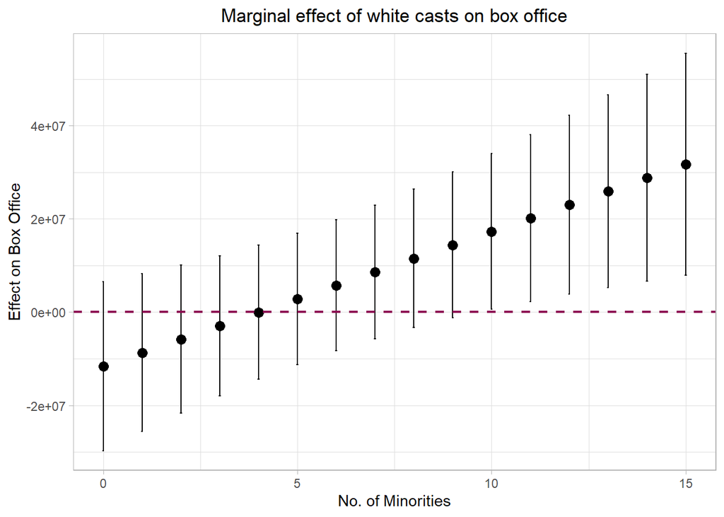

```
##
## Call:
##    felm(formula = box_office ~ white + minorities + white * minorities |      Territory | 0 | Territory, data = demo_cuk_agg)
##
## Residuals:
##        Min         1Q     Median         3Q        Max
## -138805000  -36817313  -13809514   23179924  509994752
##
## Coefficients:
##                  Estimate Cluster s.e. t value Pr(>|t|)
## white              802062       799961   1.003    0.499
## minorities        3592102      2836159   1.267    0.425
## white:minorities   -65173        48664  -1.339    0.408
##
## Residual standard error: 77050000 on 137 degrees of freedom
## Multiple R-squared(full model): 0.1437   Adjusted R-squared: 0.1187
## Multiple R-squared(proj model): 0.0621   Adjusted R-squared: 0.03472
## F-statistic(full model, *iid*):5.746 on 4 and 137 DF, p-value: 0.0002639
## F-statistic(proj model): 2.732e+13 on 3 and 1 DF, p-value: 1.406e-07
```

[5] Intercept for the two territories: China and United Kingdom

|  | effect | obs | comp | fe | idx |
| --- | --- | --- | --- | --- | --- |
| Territory.China | 55775124 | 71 | 1 | Territory | China |
| Territory.United Kingdom | 7539375 | 71 | 1 | Territory | United Kingdom |